# Example Simulation for Hierarchical Models of Species Interactions

Ben Weinstein

2/13/2019

The goal of this example is to demonstrate how to create a simple set of models to estimate interaction rates among species. We will use simulated data and try to recover the true values.

# Simulate data

Set up parameters, number of species in the network.

```r
number_of_plants<- 4
number_of_birds<- 3
cameras_per_plant<- 25
days_per_camera<- 4
```

True interaction probability. Here we draw random values to simulate the probability of each species interaction. This is alpha_i,j in the model.

```r
interaction_probability<- rbeta(n=number_of_birds*number_of_plants,1,1)

#turn into a matrix, call this alpha
alpha <- matrix(nrow=number_of_birds,ncol=number_of_plants,data=interaction_probability)
```

## Simulate binary interactions

Let’s begin with binary interactions with complete detection

```r
#observed dataframe, this is what our data will look like.
counter<-1
observed <- list()
for(bird in 1:number_of_birds){
  for(plant in 1:number_of_plants){
    for(camera in 1:cameras_per_plant){
      for(day in 1:days_per_camera){
        #simulate an interaction
        Y<-rbinom(n=1,size=1,prob=alpha[bird,plant])
        observed[[counter]]<-data.frame(bird=bird,plant=plant,camera=camera,day=day,Y=Y)
        counter<-counter+1
      }
    }
  }
}

observed<-bind_rows(observed)
#bind into a dataframe
```

What does our data look like?

```r
head(observed)
```

```
##   bird plant camera day Y
## 1    1     1      1   1 1
## 2    1     1      1   2 1
## 3    1     1      1   3 1
## 4    1     1      1   4 1
## 5    1     1      2   1 0
## 6    1     1      2   2 1
```

```r
dim(observed)
```

```
## [1] 1200    5
```

The goal now is to recover the alpha matrix.

# Model 1: Complete detection

Let’s begin with perfect together. Any variance we see is entirely due to process uncertainty in the sampling.

Model definition

$$Y_{i,j,k,d} \sim Bernoulli(\alpha_{i,j})$$
with flat priors

$$\alpha_{i,j} \sim Beta(1,1)$$

## Create a jags model.

JAGS is a bayesian tool, similiar to WINBUGS, that allows us to define models and fit them using Gibbs sampling. It is a simple and straightforward interface with R.

This isn’t the only way to write in models, but it works when its useful to test things quickly.

```r
model_string<-"
    model {

    for (x in 1:Nobs){
    #observation
    Y[x] ~ dbern(alpha[Bird[x],Plant[x]])
    }


    #Priors
    #Species level priors
    for (i in 1:Birds){
      for (j in 1:Plants){
        #Intercept
        #logit prior, then transform for plotting
        alpha[i,j] ~ dbeta(1,1)
      }
    }
    }
    "
```

## Run the model

```r
#Parameters to track, this what will be returned
ParsStage <- c("alpha")

#Jags Data passed as named list
Dat<-list(
  Y=observed$Y,
  Birds=number_of_birds,
  Bird=observed$bird,
  Plants=number_of_plants,
  Plant=observed$plant,
  Nobs=length(observed$Y))

#MCMC options
  system.time(
    model<-jags(data=Dat,parameters.to.save=ParsStage,model.file=textConnection(model_string),n.thin=1,n.iter=5000,n.burnin=4500,n.chains=2,DIC=F)
  )
```

```
## module glm loaded
```

```
## module dic loaded
```

```
##    user  system elapsed
##   0.122   0.002   0.126
```

## Look at output

There is a bit of code here to extract the index from the alpha[i,j] parameter, so we can have a seperate bird and plant column

```r
getChains<-function(model_output){
  pc<-reshape2::melt(model_output$BUGSoutput$sims.array)
  colnames(pc)<-c("Draw","chain","par","value")

  #extract parameter name
  pc$parameter<-data.frame(str_match(pc$par,"(\\w+)"))[,-1]

  #Extract index
  splitpc<-split(pc,pc$parameter)

  #single index
  splitpc[c("alpha")]<-lapply(
    splitpc[c("alpha")],function(x){
    sv<-data.frame(str_match(x$par,"(\\w+)\\[(\\d+),(\\d+)]"))[,3:4]
    colnames(sv)<-c("bird","plant")
    pc<-data.frame(x,sv)
    })

    #set chain number as character and bind
    chains<-bind_rows(splitpc)
    chains$chain<-as.character(chains$chain)

  return(chains)
}

#Get the chains of the first model
chains_m1<-getChains(model_output = model)

head(chains_m1)
```

```
##   Draw chain        par     value parameter bird plant
## 1    1     1 alpha[1,1] 0.7694022     alpha    1     1
## 2    2     1 alpha[1,1] 0.7433811     alpha    1     1
## 3    3     1 alpha[1,1] 0.7476215     alpha    1     1
## 4    4     1 alpha[1,1] 0.7883324     alpha    1     1
## 5    5     1 alpha[1,1] 0.7395611     alpha    1     1
## 6    6     1 alpha[1,1] 0.8137367     alpha    1     1
```

### View convergence

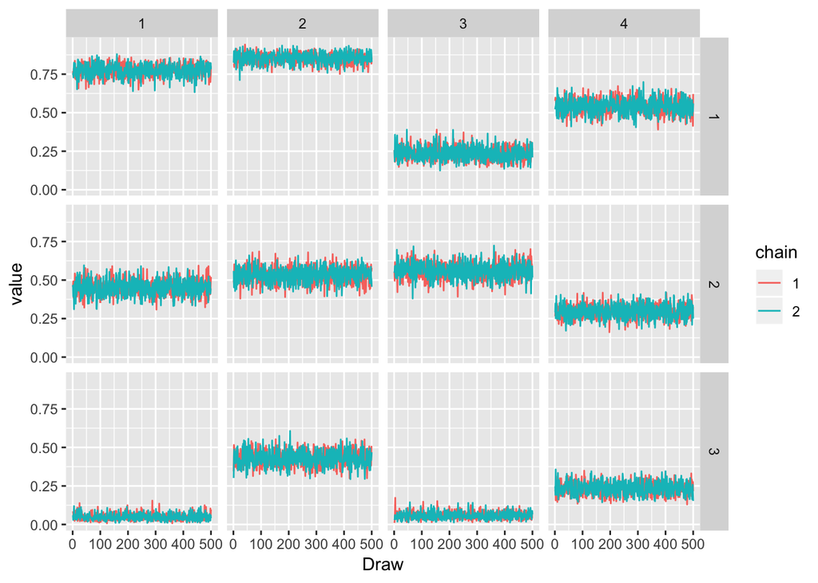

```r
ggplot(chains_m1,aes(x=Draw,col=chain,y=value)) + geom_line() + facet_grid(bird~plant)
```

## Posterior distributions

View the estimated probability of interaction among species. In red vertical line is the true probability from the simulated data.

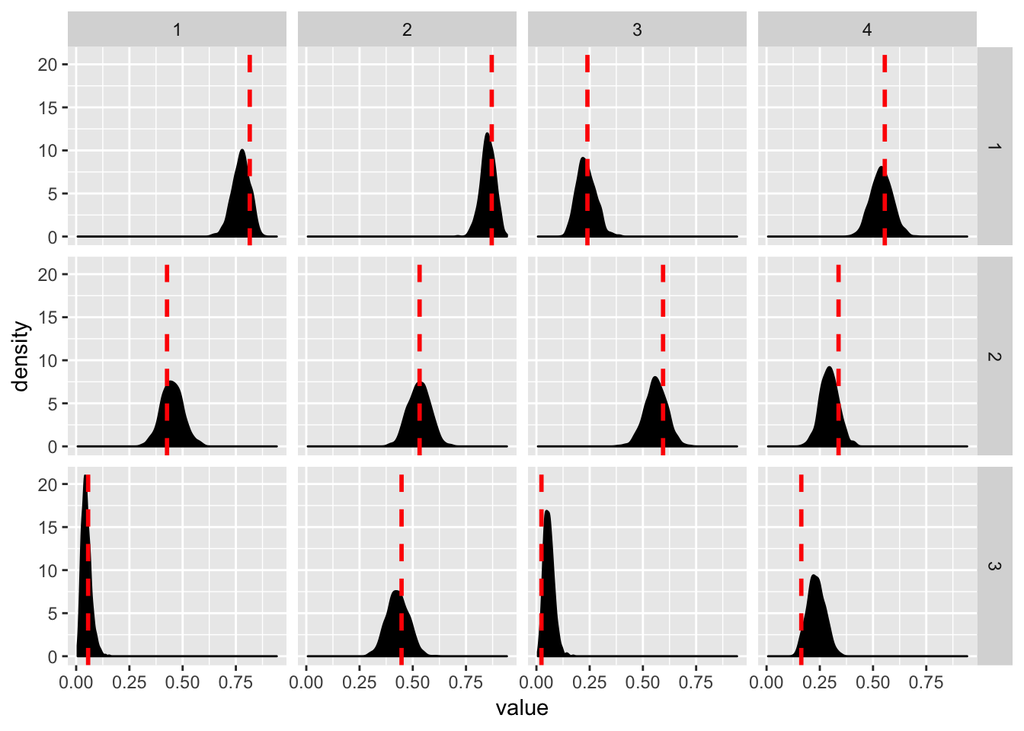

```r
true_probability <- melt(alpha)
colnames(true_probability)<-c("bird","plant","true_value")
ggplot(chains_m1,aes(x=value)) + geom_density(fill="black")  + geom_vline(data=true_probability,aes(xintercept = true_value),col="red",linetype="dashed",size=1) + facet_grid(bird~plant)
```

Excellent, our estimated posterior distributions in black overlap with the true values. As data sizes increase, the variance in the posterior will decrease.

# Model 2: Incomplete detection

Let’s go back and simulate what happens if we have hummingbird species detection probabilities.

## Simulate detection probabilities

Incomplete detection, with detection being reasonably common, omega > 0.2. As detection probability decreases below 20%, we need more data.

```r
detection_probability<-runif(n=number_of_birds,0.2,1)
```

```r
#observed dataframe
counter<-1
observed <- list()
for(bird in 1:number_of_birds){
  for(plant in 1:number_of_plants){
    for(camera in 1:cameras_per_plant){
        #simulate an interaction true state per camera
        z<-rbinom(n=1,size=1,prob=alpha[bird,plant])

        #simulate incomplete detection (omega)
        phi = z * detection_probability[bird]
      for(day in 1:days_per_camera){

        #each day is an attempt to recover true state
        Y<-rbinom(n=1,size=1,prob=phi)
        #save
        observed[[counter]]<-data.frame(bird=bird,plant=plant,camera=camera,day=day,Y=Y)
        counter<-counter+1
      }
    }
  }
}

observed<-bind_rows(observed)
```

## Define model

$$Y_{i,j,k,d} \sim Bernoulli(\phi_{i,j})$$

$$\phi_{i,j} = z_{i,j,k} * \omega_i$$
$$z_{i,j,k} \sim Bernoulli(\alpha_{i,j})$$
with flat priors

$$\alpha_{i,j} \sim Beta(1,1)$$

$$\omega_{i} ~ Beta(1,1)$$

## Create a jags model

Now that we have an observation and process model, we define them seperately in jags for ease of readability.

```r
model_string<-"
    model {

    #process model + incomplete detection

    for(i in 1:Birds){
      for(j in 1:Plants){
        for(k in 1:Cameras){
          z[i,j,k] ~ dbern(alpha[i,j])
          phi[i,j,k] = z[i,j,k] * omega[i]
        }
      }
    }

    #observation
    for (x in 1:Nobs){
      Y[x] ~ dbern(phi[Bird[x],Plant[x],Camera[x]])
    }

    #Priors
    #Species level priors
    for (i in 1:Birds){
      omega[i] ~ dbeta(1,1)
      for (j in 1:Plants){
        #Intercept
        #logit prior, then transform for plotting
        alpha[i,j] ~ dbeta(1,1)
      }
    }
    }
    "
```

## Run the model

Because we now have a latent (unobserved) state, z, we need to define a initial data matrix. We should also sample much longer and thin the chains to reduce autocorrelation.

```r
#Parameters to track, this what will be returned
ParsStage <- c("alpha","omega")

#Define latent states, jags takes this in as a function that creates a named list.
  InitStage <- function(){
    #its often useful to make the initial state present in a binary model, or a large number in a quantitative model
    z<-array(dim=c(number_of_birds,number_of_plants,cameras_per_plant),data=1)
    list(z=z)}

#Jags Data passed as named list
Dat<-list(
  Y=observed$Y,
  Birds=number_of_birds,
  Bird=observed$bird,
  Plants=number_of_plants,
  Plant=observed$plant,
  Cameras=cameras_per_plant,
  Camera=observed$camera,
  Nobs=length(observed$Y))

#MCMC options
  system.time(
    model<-jags(data=Dat,parameters.to.save=ParsStage,inits = InitStage,model.file=textConnection(model_string),n.thin=2,n.iter=100000,n.burnin=95000,n.chains=2,DIC=F)
  )
```

```
##    user  system elapsed
##  60.472   0.214  61.035
```

```r
getChains<-function(model_output){
  pc<-reshape2::melt(model_output$BUGSoutput$sims.array)
  colnames(pc)<-c("Draw","chain","par","value")

  #extract parameter name
  pc$parameter<-data.frame(str_match(pc$par,"(\\w+)"))[,-1]

  #Extract index
  splitpc<-split(pc,pc$parameter)

  #single index
  splitpc[c("omega")]<-lapply(
    splitpc[c("omega")],function(x){
    sv<-data.frame(str_match(x$par,"(\\w+)\\[(\\d+)]"))[,3]
    pc<-data.frame(x,bird=sv)
    })

  #double index
  splitpc[c("alpha")]<-lapply(
    splitpc[c("alpha")],function(x){
    sv<-data.frame(str_match(x$par,"(\\w+)\\[(\\d+),(\\d+)]"))[,3:4]
    colnames(sv)<-c("bird","plant")
    pc<-data.frame(x,sv)
    })

    #set chain number as character and bind
    chains<-bind_rows(splitpc)
    chains$chain<-as.character(chains$chain)

  return(chains)
}

#Get the chains of the first model
chains_m2<-getChains(model_output = model)

head(chains_m2)
```

```
##   Draw chain        par     value parameter bird plant
## 1    1     1 alpha[1,1] 0.9437405     alpha    1     1
## 2    2     1 alpha[1,1] 0.7564393     alpha    1     1
## 3    3     1 alpha[1,1] 0.8884220     alpha    1     1
## 4    4     1 alpha[1,1] 0.9836446     alpha    1     1
## 5    5     1 alpha[1,1] 0.8530896     alpha    1     1
## 6    6     1 alpha[1,1] 0.9538512     alpha    1     1
```

## View convergence

### Alpha: The probability of interaction

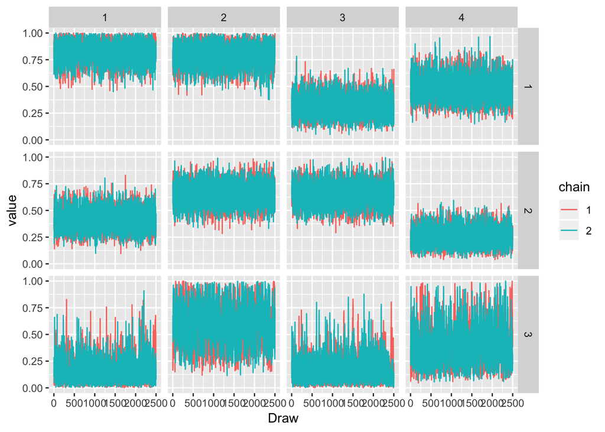

```r
chains_m2 %>% filter(parameter=="alpha") %>% ggplot(.,aes(x=Draw,col=chain,y=value)) + geom_line() + facet_grid(bird~plant)
```

### Omega: The detection probability for bird species

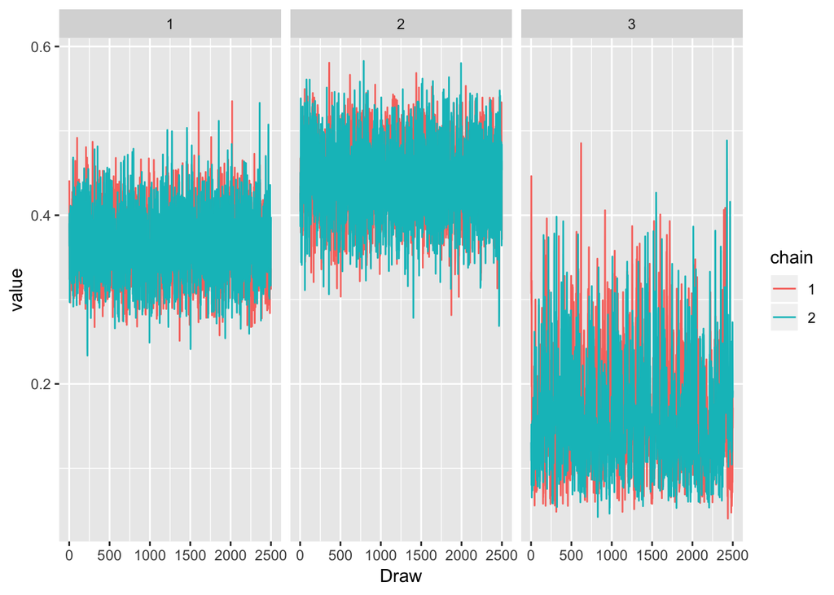

```r
chains_m2 %>% filter(parameter=="omega") %>% ggplot(.,aes(x=Draw,col=chain,y=value)) + geom_line() + facet_wrap(~bird)
```

## Posterior distributions

### Alpha

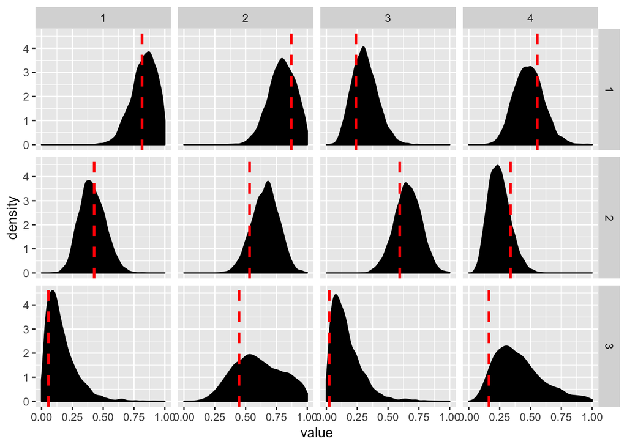

```r
chains_m2 %>% filter(parameter =="alpha") %>% ggplot(.,aes(x=value)) + geom_density(fill="black")  + geom_vline(data=true_probability,aes(xintercept = true_value),col="red",linetype="dashed",size=1) + facet_grid(bird~plant) + xlim(0,1)
```

Looking pretty good, despite incomplete detection, we can recover the true state fairly accurately.

### Omega

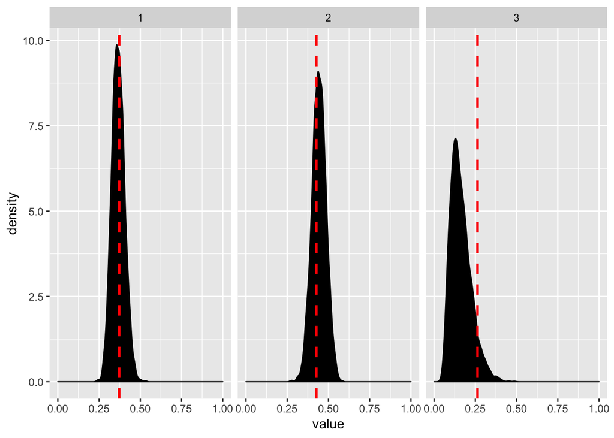

```r
true_detection_probability <- data.frame(bird=1:number_of_birds,true_value=detection_probability)
chains_m2 %>% filter(parameter =="omega") %>% ggplot(.,aes(x=value)) + geom_density(fill="black")  + geom_vline(data=true_detection_probability,aes(xintercept = true_value),col="red",linetype="dashed",size=1) + facet_wrap(~bird) + xlim(0,1)
```

# Generate networks

There are few ways to generate a network from the posterior distribution. Here is an easy one.

```r
makeNetwork<-function(chains){
  result<-matrix(nrow=number_of_birds,ncol=number_of_plants)
  for(i in 1:number_of_birds){
    for(j in 1:number_of_plants){
      #sample one row from the posterior
      sample_alpha<-chains %>% filter(bird==i,plant==j,parameter=="alpha") %>% sample_n(1) %>% .$value
      result[i,j]<-rbinom(n=1,size=1,prob=sample_alpha)
    }
  }
  return(result)
}
```

### Generate 500 networks

```r
networks<-replicate(n = 500,makeNetwork(chains_m2),simplify = F)
```

### Calculate network stats

```r
netStat<-function(network){
  data.frame(index=c("connectance","nestedness"),value=networklevel(network,index = c("connectance","nestedness")))
}

stats <- bind_rows(lapply(networks,netStat))
```

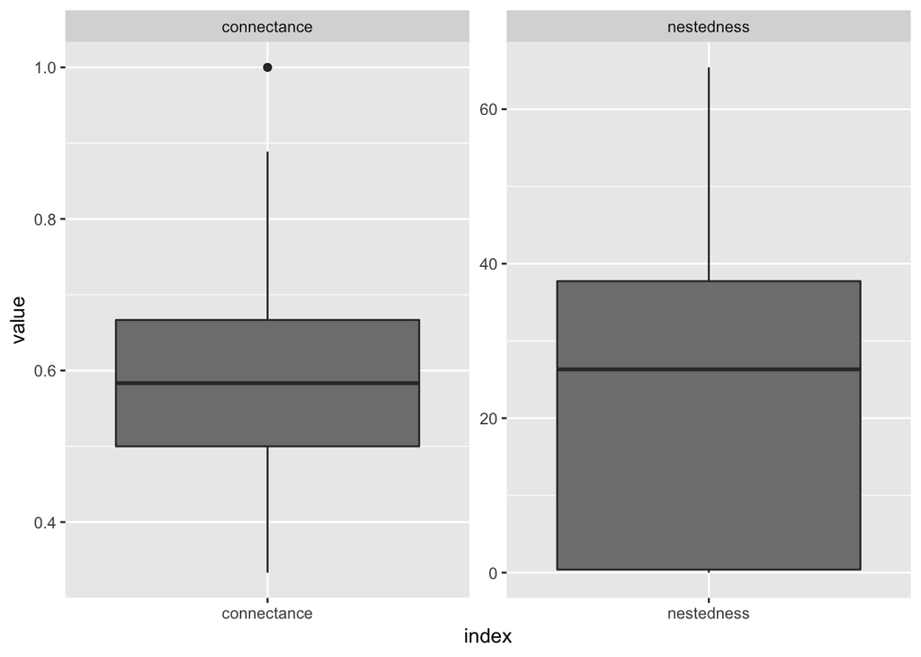

```r
ggplot(stats,aes(x=index,y=value)) + geom_boxplot(fill="grey50") + facet_wrap(~index,scale="free")
```

# Model 3 Geographic occurrence

Not all hummingbird species occur at all elevations. Simulate elevation occurrence functions, then draw cameras from across that gradient.

## True elevation functions

```r
beta_elevation <- c()
alpha_elevation <-c()

for(x in 1:number_of_birds){
  beta_elevation[x]<-rnorm(1,0,10)
  alpha_elevation[x]<-runif(1,0,1)
}

simulate_range<-function(alpha,beta,elev){
  #occurrence probability
  occ_prob<-inv.logit(alpha+beta*elev)
  return(occ_prob)
}

true_ranges<-list()
for(x in 1:number_of_birds){
  elev<-seq(0,1,0.01)
  occ<-simulate_range(alpha_elevation[x],beta_elevation[x],elev)
  true_ranges[[x]]<-data.frame(bird=as.character(x),elev=elev,occ=occ)
}

true_ranges<-bind_rows(true_ranges)
```

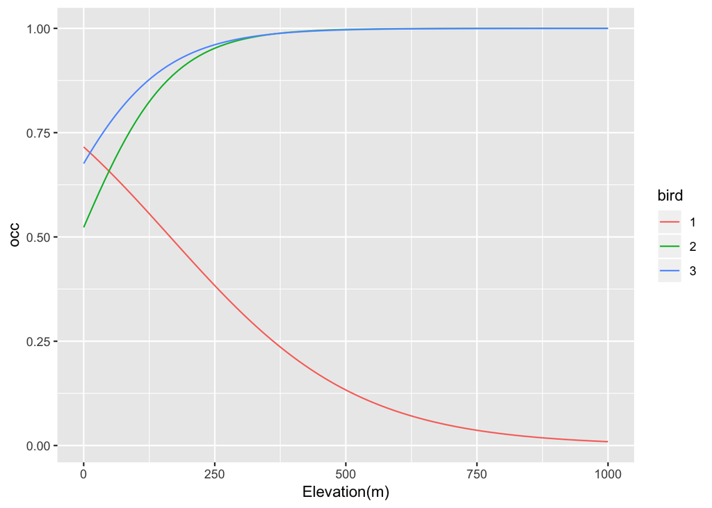

```r
#view ranges
ggplot(true_ranges,aes(x=elev*1000,y=occ,col=bird)) + geom_line() + labs(x="Elevation(m)")
```

Draw elevations for each camera

```r
#draw in km, and then change to m
camera_elev<-runif(number_of_plants * cameras_per_plant,0,1)
camera_elev<-matrix(nrow=number_of_plants,ncol=cameras_per_plant,data=camera_elev)
```

```r
#observed dataframe
counter<-1
observed <- list()
for(bird in 1:number_of_birds){
  for(plant in 1:number_of_plants){
    for(camera in 1:cameras_per_plant){
        #Is the hummingbird present at that elevation
        occ<-simulate_range(alpha=alpha_elevation[bird],beta=beta_elevation[bird],camera_elev[plant,camera])
        psi = rbinom(n=1,size=1,prob=occ)

        #effective interaction rate conditional on hummingbird presence
        rho = psi * alpha[bird,plant]

        #simulate an interaction true state per camera
        z<-rbinom(n=1,size=1,prob=rho)

        #simulate incomplete detection (omega)
        phi = z * detection_probability[bird]
      for(day in 1:days_per_camera){
        #each day is an attempt to recover true state
        Y<-rbinom(n=1,size=1,prob=phi)
        #save
        observed[[counter]]<-data.frame(bird=bird,plant=plant,camera=camera,day=day,Y=Y)
        counter<-counter+1
      }
    }
  }
}

observed<-bind_rows(observed)
```

## Define model

$$Y_{i,j,k,d} \sim Bernoulli(\phi_{i,j})$$

$$\phi_{i,j} = z_{i,j,k} * \omega_i$$

$$z_{i,j,k} \sim Bernoulli(\rho_{i,j,k})$$

$$\rho_{i,j,k} = \psi_{i,j,k} * \alpha_{i,j}$$

$$\psi_{i,j,k} \sim Bernoulli(occ_{i,j,k})$$

$$logit(occ_{i,j,k}) = \lambda_{i,elev_k} + \beta_i * elevation_k$$

with flat priors

$$\omega_{i} ~ Beta(1,1)$$

$$\alpha_{i,j} \sim Beta(1,1)$$

$$\beta_{i} \sim Normal(0,0.386)$$

$$\lambda_{i} \sim Normal(0,0.386)$$

## Create a jags model

```r
model_string<-"
    model {

    #process model + incomplete detection

    for(i in 1:Birds){
      for(j in 1:Plants){
        for(k in 1:Cameras){
          #Detection probability
          phi[i,j,k] = z[i,j,k] * omega[i]

          #Interaction probability
          z[i,j,k] ~ dbern(psi[i,j,k])

          #Occurrence
          psi[i,j,k] = occ[i,j,k] * alpha[i,j]
          logit(occ[i,j,k]) = lambda[i] + beta[i] * elevation[j,k]

        }
      }
    }

    #observation model
    for (x in 1:Nobs){
      Y[x] ~ dbern(phi[Bird[x],Plant[x],Camera[x]])
    }

    #Priors
    #Species level priors
    for (i in 1:Birds){
      #detection
      omega[i] ~ dbeta(1,1)

      #elevation intercept
      lambda[i] ~ dnorm(0,0.386)

      #effect of elevation on hummingbird occurrence
      beta[i] ~ dnorm(0,0.386)
      for (j in 1:Plants){
        #Intercept
        #logit prior, then transform for plotting
        alpha[i,j] ~ dbeta(1,1)
      }
    }
    }
    "
```

## Run the model

```r
#Parameters to track, this what will be returned
ParsStage <- c("alpha","omega","lambda","beta")

#Define latent states, jags takes this in as a function that creates a named list.
  InitStage <- function(){
    #its often useful to make the initial state present in a binary model, or a large number in a quantitative model
    z<-array(dim=c(number_of_birds,number_of_plants,cameras_per_plant),data=1)
    list(z=z)}

#Jags Data passed as named list
Dat<-list(
  Y=observed$Y,
  Birds=number_of_birds,
  Bird=observed$bird,
  Plants=number_of_plants,
  Plant=observed$plant,
  Cameras=cameras_per_plant,
  Camera=observed$camera,
  elevation=camera_elev,
  Nobs=length(observed$Y))

#MCMC options
  system.time(
    model<-jags(data=Dat,parameters.to.save=ParsStage,inits = InitStage,model.file=textConnection(model_string),n.thin=2,n.iter=200000,n.burnin=199000,n.chains=2,DIC=F)
  )
```

```
##    user  system elapsed
## 249.876   0.589 847.877
```

```r
getChains<-function(model_output){
  pc<-reshape2::melt(model_output$BUGSoutput$sims.array)
  colnames(pc)<-c("Draw","chain","par","value")

  #extract parameter name
  pc$parameter<-data.frame(str_match(pc$par,"(\\w+)"))[,-1]

  #Extract index
  splitpc<-split(pc,pc$parameter)

  #single index
  splitpc[c("omega","lambda","beta")]<-lapply(
    splitpc[c("omega","lambda","beta")],function(x){
    sv<-data.frame(str_match(x$par,"(\\w+)\\[(\\d+)]"))[,3]
    pc<-data.frame(x,bird=sv)
    })

  #double index
  splitpc[c("alpha")]<-lapply(
    splitpc[c("alpha")],function(x){
    sv<-data.frame(str_match(x$par,"(\\w+)\\[(\\d+),(\\d+)]"))[,3:4]
    colnames(sv)<-c("bird","plant")
    pc<-data.frame(x,sv)
    })

    #set chain number as character and bind
    chains<-bind_rows(splitpc)
    chains$chain<-as.character(chains$chain)

  return(chains)
}

#Get the chains of the first model
chains_m3<-getChains(model_output = model)

head(chains_m3)
```

```
##   Draw chain        par     value parameter bird plant
## 1    1     1 alpha[1,1] 0.7309376     alpha    1     1
## 2    2     1 alpha[1,1] 0.6844722     alpha    1     1
## 3    3     1 alpha[1,1] 0.7679020     alpha    1     1
## 4    4     1 alpha[1,1] 0.7406302     alpha    1     1
## 5    5     1 alpha[1,1] 0.9171773     alpha    1     1
## 6    6     1 alpha[1,1] 0.6205707     alpha    1     1
```

## View convergence

### Alpha: The probability of interaction

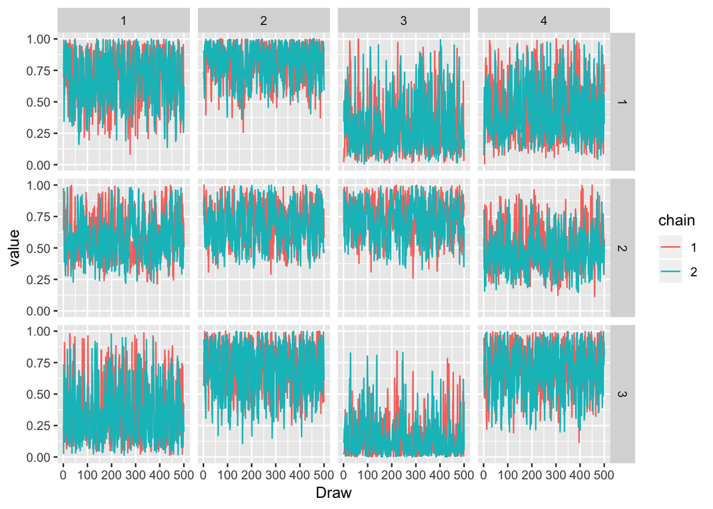

```r
chains_m3 %>% filter(parameter=="alpha") %>% ggplot(.,aes(x=Draw,col=chain,y=value)) + geom_line() + facet_grid(bird~plant)
```

### Omega: The detection probability for bird species

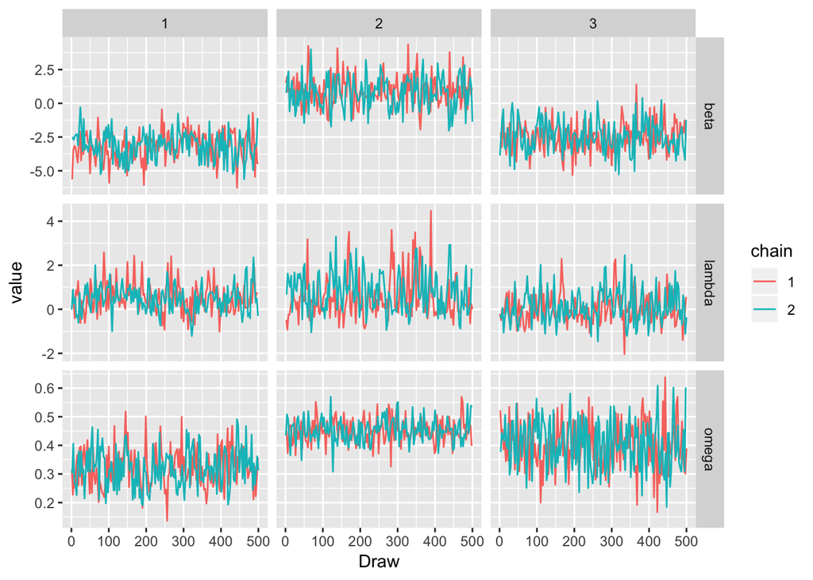

```r
chains_m3 %>% filter(parameter==c("omega","beta","lambda")) %>% ggplot(.,aes(x=Draw,col=chain,y=value)) + geom_line() + facet_grid(parameter~bird,scales="free_y")
```

## Posterior distributions

### Alpha

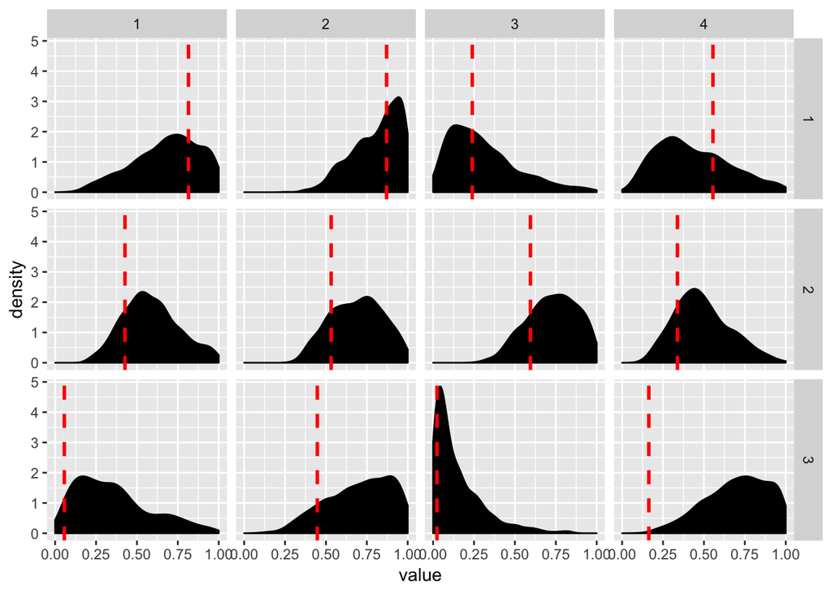

```r
chains_m3 %>% filter(parameter =="alpha") %>% ggplot(.,aes(x=value)) + geom_density(fill="black")  + geom_vline(data=true_probability,aes(xintercept = true_value),col="red",linetype="dashed",size=1) + facet_grid(bird~plant) + xlim(0,1)
```

### Omega

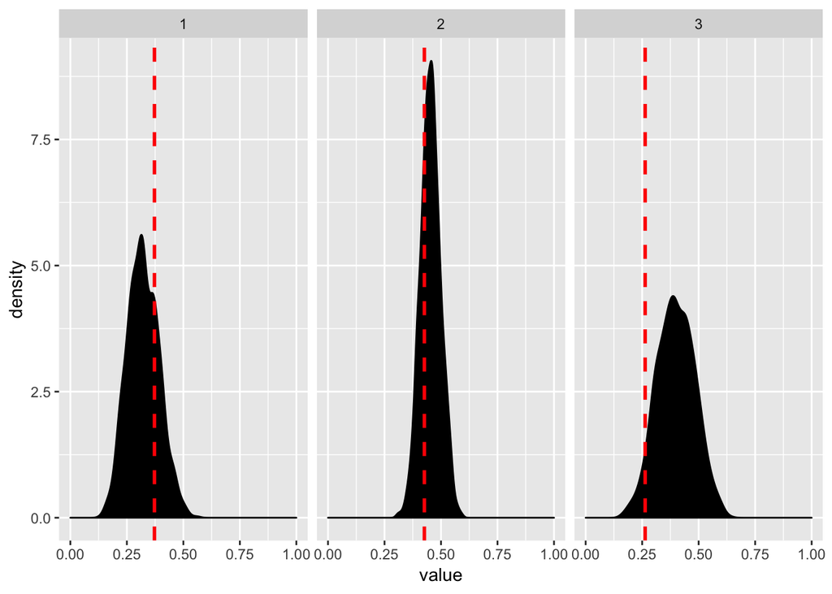

```r
true_detection_probability <- data.frame(bird=1:number_of_birds,true_value=detection_probability)
chains_m3 %>% filter(parameter =="omega") %>% ggplot(.,aes(x=value)) + geom_density(fill="black")  + geom_vline(data=true_detection_probability,aes(xintercept = true_value),col="red",linetype="dashed",size=1) + facet_wrap(~bird) + xlim(0,1)
```

### Elevation ranges

Here is a slightly fancier way to run functions across chains to help automate some of the estimation of more complex products.

```r
bird_range<-function(bird,alpha,beta,elev){
  occ<-simulate_range(alpha,beta,elev)
  data.frame(bird,elev,occ)
}

estimated_range<-chains_m3 %>% filter(parameter %in% c("lambda","beta")) %>% select(-par) %>% spread(parameter,value) %>% group_by(Draw,chain,bird) %>% do(bird_range(.$bird,.$lambda,.$beta,elev=elev)) %>% group_by(bird,elev) %>% summarize(mean=mean(occ),lower=quantile(occ,0.05),upper=quantile(occ,0.95))
```

View estimated elevation ranges in shaded, true simulated elevation ranges in dashed lines

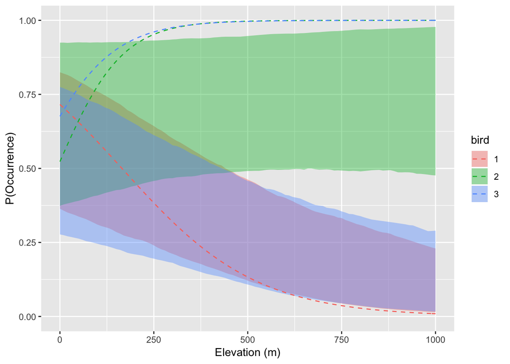

```r
ggplot(estimated_range) + geom_ribbon(alpha=0.4,aes(x=elev*1000,ymin=lower,ymax=upper,fill=bird)) + geom_line(linetype="dashed",data=true_ranges,aes(x=elev*1000,y=occ,col=bird)) + xlab("Elevation (m)") + ylab("P(Occurrence)") + ylim(0,1)
```